# ANÀLISI DE DADES ÒMIQUES

Daniel Sánchez

31 de marzo, 2025

# PROVA D’AVALUACIÓ CONTÍNUA

## Resum

Aquest estudi analitza els nivells de biomolècules en orina per identificar possibles diferències entre pacients control i pacients amb caquèxia. Es realitza una anàlisi de components principals (PCA) per explorar patrons latents en les dades i determinar quines biomolècules tenen un major impacte en la diferenciació dels grups. Els resultats obtinguts mostren que certes biomolècules tenen una major influència en la variació de les dades, fet que pot ser rellevant per estudis biomèdics.

## Objectius

A nivell general, l’objectiu principal és planificar i exevutar una versió simplificada del procés d’anàlisi de dades òmiques, alhora que es treballa amb eines i mètodes vistos en l’assignatura.

Més especificament, els objectius per l’estudi de caquèxia són:

- Analitzar les diferències en els nivells de biomolècules entre pacients control i pacients amb caquèxia.
- Aplicar tècniques d’anàlisi multivariable, especialment PCA, per detectar patrons latents en les dades.
- Identificar quines biomolècules tenen més pes en la diferenciació dels grups.

## Mètodes

### Dades

Les dades s’han obtingut del repositori facilitat a l’enunciat de l’exercici metaboData, que conté nivells de biomolècules en mostres d’orina de pacients control i pacients amb caquèxia.

### Metodologia

1. **Preprocessament de dades**:
   - S’ha importat i netejat el dataset.
   - S’ha realitzat un objecte $SummarizedExperiment()$.
   - S’ha realitzat una normalització per centrar les dades.
2. **Anàlisis exploratòries**:
   - Boxplots per visualitzar la distribució de biomolècules segons el grup.
   - PCAs per reduir la dimensionalitat i observar patrons de variabilitat.
3. **Mètodes estadístics aplicats**:
   - Càlcul de matriu de covariàncies i correlacions.
   - Càlcul de valors i vectors propis per PCA.
   - Ordenació dels pesos dels components principals.

## Resultats

La principal diferència entre `SummarizedExperiment` i `ExpressionSet`, és què el primer és més flexbile en la informació de files, permeten els basats en `GRanges`i els descrits arbitrariament per `DataFrame`s. Aquest fet fa la primera classe més idónea per a una àmplia varietat d’experiments, particularment aquells basats en seqüències, com per exemple les de *RNA-Seq* i les *Chlp-Seq*, tal com s’explica a Morgan et al. (2023).

```r
se
```

```
## class: SummarizedExperiment
## dim: 63 77
## metadata(1): patientID
## assays(1): counts
## rownames(63): X1.6.Anhydro.beta.D.glucose X1.Methylnicotinamide ...
##   pi.Methylhistidine tau.Methylhistidine
## rowData names(0):
## colnames(77): 1 2 ... 76 77
## colData names(1): Condition
```

D’aquesta primera exploració es treu la conclusió que la base de dades és de 77 pacients, que mostren o no caquèxia (columna Condition). Les dades són factors o numèriques segons ens convé i no falten valors.

Seguixo amb una exploració estadística i gràfica simple.

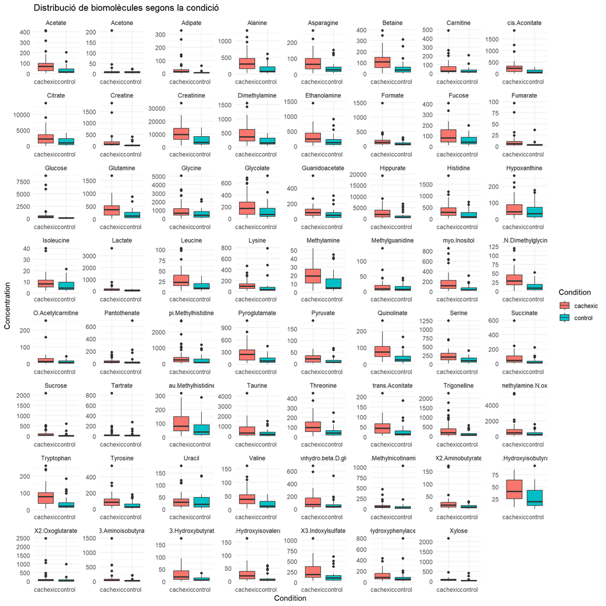

```r
resumdades_graf
```

Un cop observades les dades en cru, comencem l’estudi.

### Cerca de factors latents en les dades d’estudi

Per elaborar aquest estudi es segueixen els pasos descrits a Sánchez and Carmona (2024).

Tenim unes dades heterogènies, però amb dades del mateix tipus, és a dir, magnituds biomètriques, en aquest cas nivell de biomolècules en orina. Basem doncs l’estudi en una anàlisi de covariàncies de les dades centrades.

Es calcula la matriu de variànces ajustant a dividir per $n$ en lloc de per $(n-1)$ per fer els resultats compatibles en cas que es considerès necessari emplear més d’un mètode, com càlcul mitjançant covariànces i/o mitnjançant funcions, com ara $princomp$ i $prcomp$. Finalment, es calcula la matriu de correlacions.

Als annexes es pot observar la variable $R$ que mostra la matriu de correlacions.

### Càlcul mitjançant matriu de covariàncies

Als annexes es pot trobar la impressió de la variable $EIG$. A continuació es fa la transformació de les dades associada als components principals, obtinguda de la multiplicació de la matriu original per la matriu de vectors propis.

```r
round(vars1, 3)
```

```
##  [1] 0.772 0.113 0.047 0.030 0.011 0.008 0.005 0.004 0.002 0.002 0.001 0.001
## [13] 0.001 0.001 0.000 0.000 0.000 0.000 0.000 0.000 0.000 0.000 0.000 0.000
## [25] 0.000 0.000 0.000 0.000 0.000 0.000 0.000 0.000 0.000 0.000 0.000 0.000
## [37] 0.000 0.000 0.000 0.000 0.000 0.000 0.000 0.000 0.000 0.000 0.000 0.000
## [49] 0.000 0.000 0.000 0.000 0.000 0.000 0.000 0.000 0.000 0.000 0.000 0.000
## [61] 0.000 0.000 0.000
```

El primer component explica un 77.2 % de la variabilitat, mentre que el segon un 11.3 %.

Un cop fet el càlcul, es fa una primera representació:

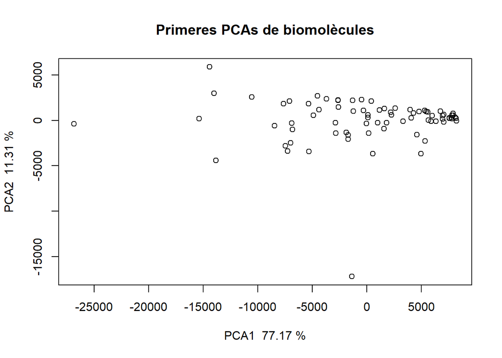

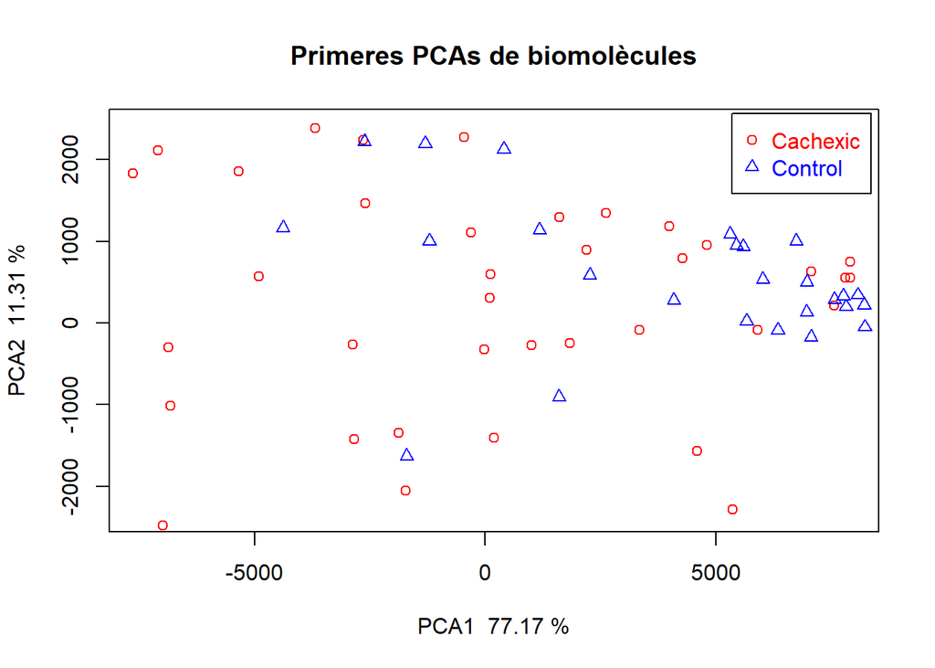

D’aquest gràfic podriem pensar que els valors pels pacients amb caquèxia són més dispersos que els valors pels pacients control.

### Càlcul dels components principals mitjançant les funcions `princomp` i `prcomp`

Tal com s’ha buscat els valors de PCA amb el mètode anterior, més manual, es poden buscar amb les funcions `princomp` i `prcomp`. Mentre que `princomp` fa exactament el mateix mètode, `prcomp` calcula els components principals mitjançant la descomposició en valors singulars de la matriu de dades.

Podem comparar les desviacions estàndard dels tres mètodes.

Primer mètode:

```r
sqrt(EIG$values)
```

```
##  [1] 6807.0993521 2605.7262607 1684.8488862 1348.1504837  814.4985158
##  [6]  691.1159565  527.1909270  483.9088285  349.0443219  307.3823410
## [11]  246.3266277  224.7851041  212.3974328  190.8009261  161.6950121
## [16]  154.7472420  140.0124654  137.5825409  126.2837074  120.0331163
## [21]  118.3037170  102.9747679   99.0227020   87.1240624   80.8218891
## [26]   68.5752516   67.0471358   63.2862546   57.1482114   50.4852525
## [31]   46.6046808   45.9843408   40.5893073   36.2882450   31.0932562
## [36]   28.1279997   25.8408732   22.5435580   21.5835546   20.0563573
## [41]   17.5105940   15.6793937   15.4425895   13.5096821   11.5055292
## [46]   10.4544508    9.0213725    8.3279991    7.4712745    6.6764517
## [51]    6.0377213    4.9003616    4.0209991    3.5944356    3.2508727
## [56]    3.0902743    2.9024616    2.5460527    2.1798922    1.6646173
## [61]    1.4099115    0.8013140    0.3820471
```

Segon mètode (`princomp`):

```r
PCAS_met2$sdev
```

```
##       Comp.1       Comp.2       Comp.3       Comp.4       Comp.5       Comp.6
## 6807.0993521 2605.7262607 1684.8488862 1348.1504837  814.4985158  691.1159565
##       Comp.7       Comp.8       Comp.9      Comp.10      Comp.11      Comp.12
##  527.1909270  483.9088285  349.0443219  307.3823410  246.3266277  224.7851041
##      Comp.13      Comp.14      Comp.15      Comp.16      Comp.17      Comp.18
##  212.3974328  190.8009261  161.6950121  154.7472420  140.0124654  137.5825409
##      Comp.19      Comp.20      Comp.21      Comp.22      Comp.23      Comp.24
##  126.2837074  120.0331163  118.3037170  102.9747679   99.0227020   87.1240624
##      Comp.25      Comp.26      Comp.27      Comp.28      Comp.29      Comp.30
##   80.8218891   68.5752516   67.0471358   63.2862546   57.1482114   50.4852525
##      Comp.31      Comp.32      Comp.33      Comp.34      Comp.35      Comp.36
##   46.6046808   45.9843408   40.5893073   36.2882450   31.0932562   28.1279997
##      Comp.37      Comp.38      Comp.39      Comp.40      Comp.41      Comp.42
##   25.8408732   22.5435580   21.5835546   20.0563573   17.5105940   15.6793937
##      Comp.43      Comp.44      Comp.45      Comp.46      Comp.47      Comp.48
##   15.4425895   13.5096821   11.5055292   10.4544508    9.0213725    8.3279991
##      Comp.49      Comp.50      Comp.51      Comp.52      Comp.53      Comp.54
##    7.4712745    6.6764517    6.0377213    4.9003616    4.0209991    3.5944356
##      Comp.55      Comp.56      Comp.57      Comp.58      Comp.59      Comp.60
##    3.2508727    3.0902743    2.9024616    2.5460527    2.1798922    1.6646173
##      Comp.61      Comp.62      Comp.63
##    1.4099115    0.8013140    0.3820471
```

Tercer mètode (`prcomp`):

```r
PCAS_met3$sdev
```

```
##  [1] 6851.7365474 2622.8131734 1695.8971940 1356.9909095  819.8395469
##  [6]  695.6479130  530.6479538  487.0820352  351.3331616  309.3979845
## [11]  247.9419016  226.2591206  213.7902178  192.0520931  162.7553186
## [16]  155.7619889  140.9305898  138.4847312  127.1118062  120.8202271
## [21]  119.0794874  103.6500196   99.6720381   87.6953739   81.3518744
## [26]   69.0249302   67.4867938   63.7012508   57.5229578   50.8163069
## [31]   46.9102885   46.2858807   40.8554696   36.5262032   31.2971486
## [36]   28.3124476   26.0103234   22.6913862   21.7250876   20.1878758
## [41]   17.6254188   15.7822105   15.5438535   13.5982711   11.5809761
## [46]   10.5230053    9.0805297    8.3826095    7.5202669    6.7202321
## [51]    6.0773133    4.9324955    4.0473666    3.6180059    3.2721902
## [56]    3.1105386    2.9214943    2.5627484    2.1941868    1.6755329
## [61]    1.4191569    0.8065686    0.3845524
```

Finalment, es poden comparar els vectors obringut els tres mètodes.

Primer mètode:

```r
head(EIG$vectors[,1],5)
```

```
## [1] -0.007370565 -0.007188872 -0.001586904 -0.002368019 -0.021231604
```

Segon mètode (`princomp`):

```r
head(PCAS_met2$loadings[,1],5)
```

```
## X1.6.Anhydro.beta.D.glucose       X1.Methylnicotinamide
##                 0.007370565                 0.007188872
##            X2.Aminobutyrate       X2.Hydroxyisobutyrate
##                 0.001586904                 0.002368019
##             X2.Oxoglutarate
##                 0.021231604
```

Tercer mètode (`prcomp`):

```r
head(PCAS_met3$rotation[,1],5)
```

```
## X1.6.Anhydro.beta.D.glucose       X1.Methylnicotinamide
##                 0.007370565                 0.007188872
##            X2.Aminobutyrate       X2.Hydroxyisobutyrate
##                 0.001586904                 0.002368019
##             X2.Oxoglutarate
##                 0.021231604
```

Els pesos adjuntats pels tres mètodes pertanyen a les cinc primeres molècules del primer component, s’adjunten els pesos de tots els components en els annexos.

### Interpretació dels components

Amb l’estudi fet observem que el primer component explica el 77.2 % de la variabilitat, mentre que el segon un 11.3 %. És per això, que l’estudi s’ha centrat en observar aquest primer component, tot i que en els gràfics també s’utilitza el segon.

Dins d’aquest primer component es poden observar els pesos de les diferents variables, en aquest cas biomolècules. Aparentment, la creatinina és la biomolècula que més afecta a la variable resposta. El citrate i el hippurate són la segona i tercera biomolècula amb més pes.

```r
head(PCAS_met2$loadings[,1][names(sort(abs(PCAS_met2$loadings[,1]), decreasing = TRUE))],5)
```

```
##             Creatinine                Citrate              Hippurate
##             0.94168067             0.21945620             0.19759572
##                Glycine Trimethylamine.N.oxide
##             0.07910261             0.05922729
```

A partir de la quarta molècula els valors s’observen molt propers a zero, per tant, podriem pensar que les tres molècules mencionades són les que més afecten.

Dels mètodes treballat es pot dir que els tres han donat resultants semblants, per tant, podríem pensar que aquests són correctes i contrastats.

## Discussió

Aquest estudi ha permès identificar patrons en les dades mitjançant PCA i altres tècniques estadístiques. Les limitacions inclouen la necessitat d’un conjunt de dades més gran, amb més observacions, per millorar la robustesa de les conclusions. També seria interessant combinar aquesta anàlisi amb tècniques de machine learning per aprofundir en la classificació dels pacients. Un altre aspecte important és que la base de dades no tenia un diccionari com a tal, per tant, de primeres, ha sigut difícil interpretar totes les dades. Cosidero important en totes aquestes bases de dades es mencionin les unitats de les variables numèriques i el context de l’estudi. Aquestes dades manquen en el dataset triat.

## Referències

- Morgan et al. (2023)
- Sánchez and Carmona (2024)
- Nutrimetabolomics (2024)

El codi i les dades utilitzades en aquest estudi estan disponibles al següent repositori de GitHub: [https://github.com/DanielSan33-4/Sanchez-Pelaez-Daniel-PAC1.git]

## Annexes

**Matriu de correlacions:**

```r
R
```

```
##                             X1.6.Anhydro.beta.D.glucose X1.Methylnicotinamide
## X1.6.Anhydro.beta.D.glucose                 1.000000000           0.058737462
## X1.Methylnicotinamide                       0.058737462           1.000000000
## X2.Aminobutyrate                            0.261133385           0.001473031
## X2.Hydroxyisobutyrate                       0.502000254           0.319199543
## X2.Oxoglutarate                            -0.011638061           0.070344207
## X3.Aminoisobutyrate                         0.066443616           0.020079514
## X3.Hydroxybutyrate                          0.213140748           0.143886414
## X3.Hydroxyisovalerate                       0.315202900           0.353413911
## X3.Indoxylsulfate                           0.284075941           0.350952439
## X4.Hydroxyphenylacetate                     0.362211859           0.193748381
## Acetate                                     0.259746510           0.173594249
## Acetone                                     0.037500937          -0.006823968
## Adipate                                     0.151231292           0.270729654
## Alanine                                     0.301051249           0.290684760
## Asparagine                                  0.308768847           0.285769035
## Betaine                                     0.150273563           0.222062519
## Carnitine                                   0.030795116           0.136299129
## Citrate                                     0.154620574           0.248873089
## Creatine                                    0.076703662           0.283040421
## Creatinine                                  0.400494419           0.349788436
## Dimethylamine                               0.433960366           0.206083336
## Ethanolamine                                0.248624683           0.201368023
## Formate                                     0.262536694           0.139937785
## Fucose                                      0.248766071           0.323705097
## Fumarate                                    0.101927612           0.087167548
## Glucose                                    -0.011195601           0.158630312
## Glutamine                                   0.352769998           0.105210513
## Glycine                                     0.253759800           0.188182296
## Glycolate                                   0.276918583           0.181770106
## Guanidoacetate                              0.156753377           0.126966123
## Hippurate                                   0.083257247           0.399567586
## Histidine                                   0.357987372           0.192360631
## Hypoxanthine                                0.248245207           0.189628387
## Isoleucine                                  0.257644353           0.246551503
## Lactate                                     0.003593093           0.040384551
## Leucine                                     0.274879173           0.209596559
## Lysine                                      0.188177337           0.027664389
## Methylamine                                 0.233427412           0.343312837
## Methylguanidine                             0.194710595           0.116717206
```

[output cut: 1225 more lines]

```
## Tartrate                            0.07687845          0.27349702
## Taurine                             0.22614625          0.32962096
## Threonine                           0.30501219          0.48379805
## Trigonelline                        0.21978876          0.22478052
## Trimethylamine.N.oxide              0.01758157          0.19421480
## Tryptophan                          0.27490347          0.41972856
## Tyrosine                            0.30888798          0.45168409
## Uracil                              0.32387266          0.39632373
## Valine                              0.32015058          0.49784200
## Xylose                             -0.04206988          0.08756952
## cis.Aconitate                       0.24658986          0.55524820
## myo.Inositol                        0.08748513          0.16786721
## trans.Aconitate                     0.04334757          0.28467437
## pi.Methylhistidine                  1.00000000          0.56022338
## tau.Methylhistidine                 0.56022338          1.00000000
```

```r
EIG
```

```
## eigen() decomposition
## $values
##  [1] 4.633660e+07 6.789809e+06 2.838716e+06 1.817510e+06 6.634078e+05
##  [6] 4.776413e+05 2.779303e+05 2.341678e+05 1.218319e+05 9.448390e+04
## [11] 6.067681e+04 5.052834e+04 4.511267e+04 3.640499e+04 2.614528e+04
## [16] 2.394671e+04 1.960349e+04 1.892896e+04 1.594757e+04 1.440795e+04
## [21] 1.399577e+04 1.060380e+04 9.805496e+03 7.590602e+03 6.532178e+03
## [26] 4.702565e+03 4.495318e+03 4.005150e+03 3.265918e+03 2.548761e+03
## [31] 2.171996e+03 2.114560e+03 1.647492e+03 1.316837e+03 9.667906e+02
## [36] 7.911844e+02 6.677507e+02 5.082120e+02 4.658498e+02 4.022575e+02
## [41] 3.066209e+02 2.458434e+02 2.384736e+02 1.825115e+02 1.323772e+02
## [46] 1.092955e+02 8.138516e+01 6.935557e+01 5.581994e+01 4.457501e+01
## [51] 3.645408e+01 2.401354e+01 1.616843e+01 1.291997e+01 1.056817e+01
## [56] 9.549795e+00 8.424283e+00 6.482385e+00 4.751930e+00 2.770951e+00
## [61] 1.987851e+00 6.421042e-01 1.459600e-01
```

[output cut: 834 more lines]

**Pesos de tots els components segons el primer mètode treballat:**

```r
EIG$vectors
```

```
##                [,1]          [,2]          [,3]          [,4]          [,5]
##  [1,] -0.0073705650  0.0047775128 -0.0124724661 -0.0172052307 -0.0684179224
##  [2,] -0.0071888723 -0.0126078246  0.0023579378  0.0151852943  0.0188798763
##  [3,] -0.0015869038  0.0031188547  0.0038432040  0.0019091181 -0.0063860315
##  [4,] -0.0023680187  0.0014833100  0.0002619370  0.0017345157 -0.0027342069
##  [5,] -0.0212316043  0.0257750325  0.0687933552  0.0152917210  0.0853653773
##  [6,] -0.0096481157  0.0082726397  0.0113934179  0.0016075536 -0.0806994054
##  [7,] -0.0024423997  0.0017245359  0.0040291693  0.0057795888 -0.0094986966
##  [8,] -0.0023581616 -0.0013448929 -0.0003473637  0.0055777649  0.0013047167
##  [9,] -0.0200924404 -0.0101662622 -0.0200944571 -0.0107874222 -0.0526870561
## [10,] -0.0091624317  0.0053686564 -0.0131245995  0.0105156462 -0.0221529776
## [11,] -0.0062654655  0.0022581947 -0.0145207138  0.0215621136 -0.0049765155
## [12,] -0.0008158222  0.0023174349  0.0063719545  0.0046184882 -0.0033948800
## [13,] -0.0030140039 -0.0052730454 -0.0021545624  0.0185606859 -0.0019855051
## [14,] -0.0277339653  0.0053371536 -0.0003289902  0.0813660177 -0.0150659675
```

[output cut: 817 more lines]

```r
PCAS_met2$loadings
```

```
##
## Loadings:
##                             Comp.1 Comp.2 Comp.3 Comp.4 Comp.5 Comp.6 Comp.7
## X1.6.Anhydro.beta.D.glucose
## X1.Methylnicotinamide
## X2.Aminobutyrate
## X2.Hydroxyisobutyrate
## X2.Oxoglutarate                                                -0.129 -0.161
## X3.Aminoisobutyrate
## X3.Hydroxybutyrate
## X3.Hydroxyisovalerate
## X3.Indoxylsulfate
## X4.Hydroxyphenylacetate
## Acetate
## Acetone
## Adipate
## Alanine
## Asparagine
## Betaine
## Carnitine
## Citrate                      0.219  0.187 -0.839 -0.262        -0.249 -0.165
## Creatine
## Creatinine                   0.942  0.144  0.227  0.125 -0.108
## Dimethylamine                                            0.117
## Ethanolamine
## Formate
## Fucose
## Fumarate
## Glucose                                    0.333 -0.910
## Glutamine                                                0.114  0.106
## Glycine                                   -0.257 -0.118  0.302  0.722  0.212
## Glycolate
## Guanidoacetate
## Hippurate                    0.198 -0.960 -0.127
## Histidine                                                       0.149  0.156
## Hypoxanthine
## Isoleucine
## Lactate                                          -0.170
## Leucine
## Lysine
```

[output cut: 684 more lines]

```
## SS loadings      1.000   1.000   1.000   1.000   1.000   1.000   1.000   1.000
## Proportion Var   0.016   0.016   0.016   0.016   0.016   0.016   0.016   0.016
## Cumulative Var   0.540   0.556   0.571   0.587   0.603   0.619   0.635   0.651
##                Comp.42 Comp.43 Comp.44 Comp.45 Comp.46 Comp.47 Comp.48 Comp.49
## SS loadings      1.000   1.000   1.000   1.000   1.000   1.000   1.000   1.000
## Proportion Var   0.016   0.016   0.016   0.016   0.016   0.016   0.016   0.016
## Cumulative Var   0.667   0.683   0.698   0.714   0.730   0.746   0.762   0.778
##                Comp.50 Comp.51 Comp.52 Comp.53 Comp.54 Comp.55 Comp.56 Comp.57
## SS loadings      1.000   1.000   1.000   1.000   1.000   1.000   1.000   1.000
## Proportion Var   0.016   0.016   0.016   0.016   0.016   0.016   0.016   0.016
## Cumulative Var   0.794   0.810   0.825   0.841   0.857   0.873   0.889   0.905
##                Comp.58 Comp.59 Comp.60 Comp.61 Comp.62 Comp.63
## SS loadings      1.000   1.000   1.000   1.000   1.000   1.000
## Proportion Var   0.016   0.016   0.016   0.016   0.016   0.016
## Cumulative Var   0.921   0.937   0.952   0.968   0.984   1.000
```

**Pesos de tots els components segons el tercer mètode treballat:**

```r
PCAS_met3$rotation
```

```
##                                      PC1           PC2           PC3
## X1.6.Anhydro.beta.D.glucose 0.0073705650  0.0047775128  0.0124724661
## X1.Methylnicotinamide       0.0071888723 -0.0126078246 -0.0023579378
## X2.Aminobutyrate            0.0015869038  0.0031188547 -0.0038432040
## X2.Hydroxyisobutyrate       0.0023680187  0.0014833100 -0.0002619370
## X2.Oxoglutarate             0.0212316043  0.0257750325 -0.0687933552
## X3.Aminoisobutyrate         0.0096481157  0.0082726397 -0.0113934179
## X3.Hydroxybutyrate          0.0024423997  0.0017245359 -0.0040291693
## X3.Hydroxyisovalerate       0.0023581616 -0.0013448929  0.0003473637
## X3.Indoxylsulfate           0.0200924404 -0.0101662622  0.0200944571
## X4.Hydroxyphenylacetate     0.0091624317  0.0053686564  0.0131245995
## Acetate                     0.0062654655  0.0022581947  0.0145207138
## Acetone                     0.0008158222  0.0023174349 -0.0063719545
## Adipate                     0.0030140039 -0.0052730454  0.0021545624
## Alanine                     0.0277339653  0.0053371536  0.0003289902
## Asparagine                  0.0056489585  0.0039048906 -0.0060285261
## Betaine                     0.0056298088  0.0025126525 -0.0079729477
## Carnitine                   0.0024653825  0.0042640056 -0.0106847719
## Citrate                     0.2194561979  0.1873532182 -0.8387294030
## Creatine                    0.0071002685 -0.0615312342 -0.0129536123
## Creatinine                  0.9416806687  0.1436246701  0.2274257694
## Dimethylamine               0.0388025987  0.0091307666  0.0019893210
## Ethanolamine                0.0303773866  0.0176576793 -0.0292038641
## Formate                     0.0181786141  0.0040974056 -0.0205865191
## Fucose                      0.0095168598  0.0034410453 -0.0025113892
## Fumarate                    0.0010202294  0.0013305048 -0.0032516191
## Glucose                     0.0320750612  0.0569324394  0.3326002001
## Glutamine                   0.0278575074  0.0229870114 -0.0563683020
## Glycine                     0.0791026073  0.0741286514 -0.2573908640
## Glycolate                   0.0145728062  0.0053078251  0.0054158607
## Guanidoacetate              0.0051942710  0.0005414396 -0.0049121192
## Hippurate                   0.1975957249 -0.9601090543 -0.1265306803
## Histidine                   0.0321503967  0.0069640644 -0.0371075638
## Hypoxanthine                0.0066106507  0.0041234658 -0.0065158212
## Isoleucine                  0.0004928095  0.0001887086 -0.0006541512
## Lactate                     0.0105073404  0.0098378145  0.0627559682
## Leucine                     0.0021044991  0.0012666991  0.0008135217
## Lysine                      0.0052488167  0.0028937298  0.0019969154
## Methylamine                 0.0012301660 -0.0007444369 -0.0007831524
## Methylguanidine             0.0011894641  0.0015644234 -0.0052871661
```

[output cut: 1289 more lines]

```
## Tartrate                     0.0242171572 -0.0070884635  7.500734e-03
## Taurine                     -0.0048241525 -0.0093242759  1.539848e-03
## Threonine                   -0.0310018105 -0.0094657408  1.404753e-02
## Trigonelline                 0.0050355235 -0.0146831934  2.443924e-03
## Trimethylamine.N.oxide      -0.0034457107 -0.0038719853  2.302443e-03
## Tryptophan                  -0.0243372727  0.0187950004  1.086263e-02
## Tyrosine                    -0.1479753788  0.0133951950  1.112383e-03
## Uracil                      -0.0692163850  0.0034734389  7.806482e-04
## Valine                      -0.0865720430  0.0484144166 -2.489052e-02
## Xylose                      -0.0189105820  0.0151658112  9.141998e-04
## cis.Aconitate                0.0106928629 -0.0358566156  1.674713e-02
## myo.Inositol                 0.0079652295  0.0078554282  1.253819e-03
## trans.Aconitate             -0.0777490067  0.0191801352 -9.320760e-03
## pi.Methylhistidine           0.0027007025  0.0039714548 -2.204843e-03
## tau.Methylhistidine         -0.0163786592 -0.0052501996 -2.011711e-03
```

```r
PCAS_met2$loadings[,1][names(sort(abs(PCAS_met2$loadings[,1]), decreasing = TRUE))]
```

```
##                  Creatinine                     Citrate
##                0.9416806687                0.2194561979
##                   Hippurate                     Glycine
##                0.1975957249                0.0791026073
##      Trimethylamine.N.oxide                     Taurine
##                0.0592272865                0.0570777518
##                Trigonelline               Dimethylamine
##                0.0388583327                0.0388025987
##                   Histidine                     Glucose
##                0.0321503967                0.0320750612
##               cis.Aconitate                Ethanolamine
##                0.0318446599                0.0303773866
##                   Glutamine                     Alanine
##                0.0278575074                0.0277339653
##          pi.Methylhistidine               Pyroglutamate
##                0.0260383952                0.0234748835
##             X2.Oxoglutarate           X3.Indoxylsulfate
##                0.0212316043                0.0200924404
##                      Serine                     Formate
##                0.0182071992                0.0181786141
##                   Glycolate                      Xylose
##                0.0145728062                0.0139710013
##                     Lactate         X3.Aminoisobutyrate
##                0.0105073404                0.0096481157
##                      Fucose                   Succinate
##                0.0095168598                0.0094506666
##     X4.Hydroxyphenylacetate                    Tyrosine
##                0.0091624317                0.0088883207
##                   Threonine                myo.Inositol
##                0.0088793981                0.0075144014
## X1.6.Anhydro.beta.D.glucose       X1.Methylnicotinamide
##                0.0073705650                0.0071888723
##                    Creatine                Hypoxanthine
##                0.0071002685                0.0066106507
##         tau.Methylhistidine                     Acetate
##                0.0065001408                0.0062654655
##                    Tartrate                  Asparagine
##                0.0056529095                0.0056489585
##                     Betaine                     Sucrose
##                0.0056298088                0.0053516046
```

[output cut: 9 more lines]

```
##                0.0030140039                0.0025934557
##         N.N.Dimethylglycine                   Carnitine
##                0.0025904768                0.0024653825
##          X3.Hydroxybutyrate       X2.Hydroxyisobutyrate
##                0.0024423997                0.0023680187
##       X3.Hydroxyisovalerate                     Leucine
##                0.0023581616                0.0021044991
##           O.Acetylcarnitine            X2.Aminobutyrate
##                0.0018213825                0.0015869038
##                 Methylamine             Methylguanidine
##                0.0012301660                0.0011894641
##                    Fumarate                     Acetone
##                0.0010202294                0.0008158222
##                  Isoleucine
##                0.0004928095
```

Morgan, Martin, Valerie Obenchain, Jim Hester, and Hervé Pagès. 2023. *SummarizedExperiment for Coordinating Experimental Assays, Samples, and Regions of Interest*. https://bioconductor.org/packages/release/bioc/vignettes/SummarizedExperiment/inst/doc/SummarizedExperiment.html.

Nutrimetabolomics. 2024. “metaboData: Repositori de Dades Metabolòmiques.” https://github.com/nutrimetabolomics/metaboData.

Sánchez, Alex, and Francesc Carmona. 2024. “Casos y Ejemplos de Análisis Multivariante Con r.” https://aspteaching.github.io/AMVCasos/#ejemplo-pca-1-búsqueda-de-factores-latentes-en-datos-ecológicos1.